# Estudo de Caso 01: Comparação do IMC médio de alunos do PPGEE-UFMG ao longo de dois semestres

EEE933 - Planejamento e Análise de Experimentos

Alexandra Milaya Soto Aponte,

11 de setembro de 2026

# Resumo

# Projeto experimental

## Objetivo do Experimento e Hipóteses a serem Testadas

O objetivo principal deste experimento é verificar se existe diferença estatisticamente significativa no IMC médio dos alunos de pós-graduação do PPGEE-UFMG entre os semestres 2016-2 e 2017-2. Para tanto, as amostras foram separadas em subcategorias de análise classificadas por sexo e semestre:

- Homens em 2016-2 vs. Homens em 2017-2
- Mulheres em 2016-2 vs. Mulheres em 2017-2

Para cada subpopulação (separada por sexo), definem-se as seguintes hipóteses bilaterais, por não haver razão teórica prévia para supor a direção de uma eventual diferença do IMC médio da população de 2016-2 em relação à população de 2017-2:

- **Hipótese Nula ($H_0$):** Não há diferença na média do IMC entre os alunos de 2016-2 e 2017-2.
- **Hipótese Alternativa ($H_1$):** Há diferença significativa na média do IMC entre os semestres 2016-2 e 2017-2.

$$\begin{cases}
H_0: \mu_{2016} - \mu_{2017} = 0 \\
H_1: \mu_{2016} - \mu_{2017} \neq 0
\end{cases}$$

## Tipos de Teste Utilizados

Para a comparação simples entre duas populações independentes, é necessário verificar previamente duas premissas essenciais:

1. Normalidade;
2. Igualdade de variâncias.

A premissa de normalidade será avaliada por meio do teste de Shapiro-Wilk. Enquanto a igualdade de variâncias será verificada utilizando o teste de Fligner-Killeen. A validação dessas premissas determinará a escolha do teste de hipótese para a comparação das médias do IMC entre os semestres:

1. Teste $t$ de Student tradicional: aplicado caso as variâncias sejam homogêneas.
2. Teste $t$ de Welch: aplicado caso sejam identificadas variâncias distintas.

É comum, na prática, optar-se diretamente pelo teste de Welch, uma vez que essa escolha dispensa a etapa de verificação da igualdade de variâncias (Fligner-Killeen), simplificando o fluxo de análise. Essa conveniência, no entanto, em caso de igualdade de variâncias, significa uma perda de poder de teste que pode ser especialmente relevante em amostras com poucas observações, como é o caso deste estudo. Por esse motivo, optou-se por verificar explicitamente a igualdade de variâncias e aplicar o teste mais adequado a cada caso, em vez de adotar Welch de forma indiscriminada.

## Descrição da Coleta e Consolidação dos Dados

Por se tratar de um estudo retrospectivo, isto é, uma análise baseada em dados previamente coletados, a definição teórica do tamanho amostral e a estimação prévia do tamanho do efeito não puderam ser planejadas ativamente antes da coleta. Dessa forma, essas métricas serão reportadas e discutidas durante a apresentação dos resultados dos testes de hipótese. Esta subseção é dedicada exclusivamente ao procedimento de filtragem, tratamento e consolidação das bases de dados.

Os dados do semestre 2016-2 foram recuperados do arquivo `data/imc_20162.csv`, enquanto os do semestre 2017-2 correspondem ao arquivo `data/CS01_20172.csv`. Conforme especificado no enunciado, a base de 2016-2 inclui registros de turmas de graduação, e ambas as tabelas possuem divergências na estrutura das colunas. A consolidação dos dados exigiu as seguintes etapas de pré-processamento:

1. **Filtragem dos dados de 2016-2:** isolamento dos alunos pertencentes à pós-graduação (`Course == "PPGEE"`).
2. **Padronização dos nomes das colunas:** renomeação dos campos no arquivo de 2017-2 (`height.m` $\rightarrow$ `Height.m` e `Sex` $\rightarrow$ `Gender`) para alinhar com o esquema do arquivo de 2016-2.
3. **Conversão para tipo numerico**
4. **Cálculo do IMC:** criação da variável `BMI` em ambas as tabelas, aplicando a fórmula:
   $$\mathrm{BMI} =
   \frac{\mathrm{Peso}}{\mathrm{Altura}^2}$$
5. **Estruturação por subpopulações:** separação das observações por sexo e semestre para a criação dos conjuntos agregados que compõem os grupos de análise, alocados nas seguintes variáveis:
   - `fem_2016`, `fem_2017`: subpopulações femininas dos semestres 2016-2 e 2017-2, respectivamente.
   - `masc_2016`, `masc_2017`: subpopulações masculinas dos semestres 2016-2 e 2017-2, respectivamente.
   - `fem`, `masc`: agregados das subpopulações femininas e masculinas, englobando ambos os semestres.
   - `todos`: tabela consolidada com a totalidade dos dados, classificados por sexo e semestre.

# Análise Exploratória dos Dados

A fim de compreender o comportamento dos dados, foi realizada uma exploração inicial por meio de um gráfico de *boxplot* para comparar a distribuição do IMC entre as subpopulações de cada semestre.

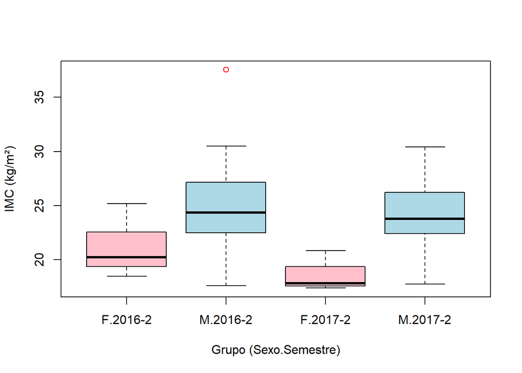

Distribuição do IMC por Sexo e Semestre

Em seguida, os principais parâmetros estatísticos (tamanho amostral $n$, média e desvio-padrão) de cada subcategoria foram calculados e resumidos na Tabela @ref(tab:tabela-resumo).

Estatísticas descritivas do IMC por subamostra

| Grupo | n | Média | Desvio Padrão |
| --- | --- | --- | --- |
| Feminino 2016-2 | 7 | 21.08 | 2.42 |
| Feminino 2017-2 | 4 | 18.45 | 1.60 |
| Masculino 2016-2 | 21 | 24.94 | 4.32 |
| Masculino 2017-2 | 21 | 24.29 | 3.44 |

# Análise Estatística

## Validação das premissas do modelo

### Normalidade

O teste de Shapiro-Wilk foi realizado para cada uma das subamostras em análise. Os resultados seguem na Tabela @ref(tab:st-table).

Resultado do p-valor para o teste de Shapiro-Wilk

| Genero | Semestre | p-valor |
| --- | --- | --- |
| F | 2016-2 | 0.467 |
| M | 2016-2 | 0.127 |
| F | 2017-2 | 0.037 |
| M | 2017-2 | 0.621 |

Os resultados indicam que as amostras masculinas (2016-2 e 2017-2) e a amostra feminina de 2016-2 apresentam comportamento compatível com a distribuição normal ($p\text{-valor} > 0{,}05$), não permitindo a rejeição da hipótese nula de normalidade.

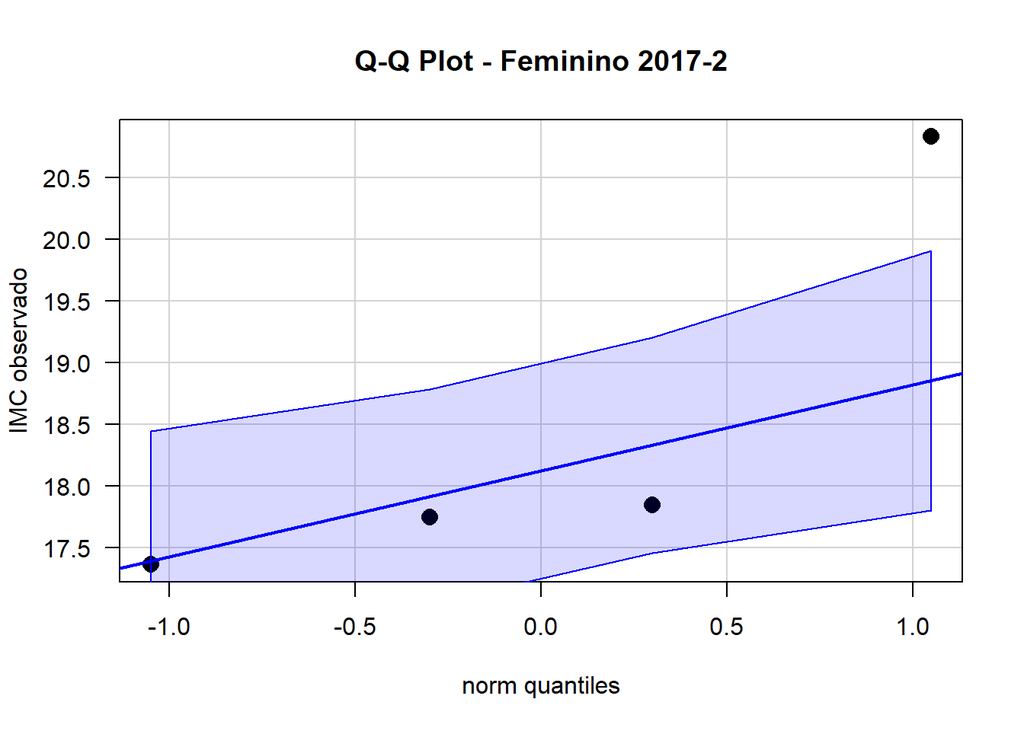

Gráficos quantil-quantil do IMC do sub grupo feminino 2017

O gráfico quantil-quantil (Q-Q plot) indica que a violação da premissa de normalidade para a amostra feminina 2017-2 é provocada por apenas um único valor discrepante. Dessa forma, é razoável assumir a premissa de normalidade para as análises subsequentes, uma vez que o teste $t$ de Student é robusto a pequenas desviações da distribuição normal.

Tal assunção é interessante, uma vez que o teste $t$ de Student tradicional apresenta a vantagem de proporcionar maior poder de teste em relação ao teste de Welch, quando a premissa de homogeneidade de variâncias é de fato satisfeita.

### Igualdade de Variância

Resultado do teste de Fligner-Killeen para igualdade de variâncias entre semestres

| Grupo de Comparação | Estatística (Chi²) | p-valor |
| --- | --- | --- |
| Feminino (2016-2 vs 2017-2) | 0.709 | 0.400 |
| Masculino (2016-2 vs 2017-2) | 0.083 | 0.774 |

De acordo com os resultados do teste de Fligner-Killeen apresentados na Tabela @ref(tab:tabela-var), tanto a subpopulação feminina ($p\text{-valor} > 0{,}05$) quanto a masculina ($p\text{-valor} > 0{,}05$) mantiveram a premissa de homocedasticidade. Com a confirmação da igualdade de variâncias e da normalidade, o teste $t$ de Student para amostras independentes com variâncias iguais é o procedimento adequado para a comparação das médias do IMC entre os semestres 2016-2 e 2017-2.

### Efeito minimamente relevante ($\delta^*$)

O valor do menor efeito de interesse prático foi fixado *a priori*, antes do exame dos dados, em $\delta^* = 1\ \mathrm{kg/m^2}$, tal valor foi adotado nos 2 casos analisados, por ser a relevância prática uma propriedade da grandeza medida e não da dispersão de cada subamostra. Essa escolha não pretende representar um limiar de relevância clínica ou prática específico, mas sim estabelecer uma referência comum e consistente, que permite comparar a sensibilidade do teste entre os dois grupos em igualdade de condições, evitando que diferenças nos resultados da discussão de potência decorram da escolha de valores de referência distintos para cada subpopulação, e não de diferenças reais em seus tamanhos amostrais ou variabilidades.

### Nível de significância e tamanho amostral

Os testes foram executados com `conf.level = 0.95`, o que corresponde a um nível de significância $\alpha = 0{,}05$.

## Teste de Hipóteses

Os testes de hipótese foram realizados seguindo as hipóteses definidas na seção de Objetivo do Experimento e Hipóteses a serem Testadas. Os testes foram realizados para obter informações sobre a inferência da diferença da média do IMC para as subpopulações femininas 2016-2 vs. 2017-2, e repetidos para as subpopulações masculinas 2016-2 vs. 2017-2. Portanto, esta seção se divide em dois casos: subpopulação masculina e subpopulação feminina

### Caso 1: Subpopulação Masculina

```
##
##  Two Sample t-test
##
## data:  masc_2016$BMI and masc_2017$BMI
## t = 0.53979, df = 40, p-value = 0.5923
## alternative hypothesis: true difference in means is not equal to 0
## 95 percent confidence interval:
##  -1.784943  3.085836
## sample estimates:
## mean of x mean of y
##  24.93595  24.28551
```

O teste resultou em $p = 0{,}5923$, sendo o intervalo de confiança de 95% para a diferença entre as médias: $[-1{,}7849;\ 3{,}0858]\ \mathrm{kg/m^2}$, e médias amostrais de $24{,}9360\ \mathrm{kg/m^2}$ (2016-2) e $24{,}2855\ \mathrm{kg/m^2}$ (2017-2). Como o intervalo de confiança contém o valor zero e, o $p$-valor obtido é maior que $\alpha = 0{,}05$, falhou-se em rejeitar a hipótese nula, não havendo evidências estatísticas suficientes para afirmar que o IMC médio da subpopulação masculina difere entre os semestres 2016-2 e 2017-2.

### Caso 2: População Feminina

```
##
##  Two Sample t-test
##
## data:  fem_2016$BMI and fem_2017$BMI
## t = 1.9308, df = 9, p-value = 0.08556
## alternative hypothesis: true difference in means is not equal to 0
## 95 percent confidence interval:
##  -0.4527037  5.7283762
## sample estimates:
## mean of x mean of y
##  21.08443  18.44660
```

O teste resultou em $p = 0{,}08556$, sendo o intervalo de confiança de 95% para a diferença entre as médias: $[-0{,}4527;\ 5{,}7284]\ \mathrm{kg/m^2}$, com médias amostrais de $21{,}0844\ \mathrm{kg/m^2}$ (2016-2) e $18{,}4466\ \mathrm{kg/m^2}$ (2017-2). Como o intervalo de confiança contém o valor zero, e o $p$-valor obtido, embora relativamente próximo de $\alpha = 0{,}05$, ainda é maior que esse limiar, falhou-se em rejeitar a hipótese nula, não havendo evidências estatísticas suficientes para afirmar que o IMC médio da subpopulação feminina difere entre os semestres 2016-2 e 2017-2.

## Resultados e Discussões

### Discussão sobre o Teste de Hipóteses

O objetivo deste experimento era verificar se existia diferença significativa no IMC médio entre duas populações de estudantes: alunos de pós-graduação do PPGEE-UFMG nos semestres 2016-2 e 2017-2.

Os testes foram realizados sobre essas populações, separadas por gênero. Em ambos os casos, falhou-se em rejeitar a hipótese nula, não havendo evidências estatísticas suficientes para afirmar que o IMC médio difere entre os semestres, tanto para a subpopulação masculina quanto para a feminina. No entanto, devido ao tamanho reduzido de cada subamostra, é interessante realizar uma análise de poder do teste, que pode ajudar a avaliar a possibilidade de um Erro Tipo II, isto é, a hipótese de que se falhou em rejeitar $H_0$ mesmo havendo, de fato, uma diferença real entre as populações.Por esse motivo, a seção a seguir traz essa discussão à tona.

### Discussão sobre o Poder do Teste

É convecioanl definir o poder estatístico em 80% ($1 - \beta = 0{,}80$). Contudo, por se tratar de um estudo retrospectivo, em que os dados já haviam sido previamente coletados, não houve controle sobre o tamanho amostral para garantir essa potência *a priori*.

Para poder levar a cabo o calculo de poder de teste devemos conhecer a variância populacional $\sigma^2$, como a mesma é desconhecida, é necessário estimá-la a partir dos dados amostrais. Assumindo a premissa de igualdade de variância entre as subpopulações ($\sigma_1^2 \approx \sigma_2^2$), confirmada pelo teste de Fligner-Killeen, utiliza-se o estimador ponderado da variância agrupada ($S_p^2$):

$$\begin{equation}
S_p^2 = \frac{(n_1 - 1)S_1^2 + (n_2 - 1)S_2^2}{n_1 + n_2 - 2}
\label{eq:var-agrupada}
\end{equation}$$

em que $S_1^2$ e $S_2^2$ são as variâncias amostrais das subpopulações de 2016-2 e 2017-2, e $n_1$, $n_2$ os respectivos tamanhos amostrais. O desvio-padrão agrupado ($S_p = \sqrt{S_p^2}$) é então utilizado como parâmetro de dispersão no cálculo do poder do teste.

```
## Desvio Padrão - masculino - : 3.905
```

```
## Desvio Padrão - femenino - : 2.18
```

```r
# Poder do teste para detectar delta* = 1, dado o n e Sp já calculados
poder_masc <- power.t.test(
  n = n1_masc,
  delta = 1,
  sd = sd_pooled_masc,
  sig.level = 0.05,
  type = "two.sample",
  alternative = "two.sided"
)$power

#Usamos como caso balanceado por simplicidade
poder_fem <- power.t.test(
  n = n1_fem,
  delta = 1,
  sd = sd_pooled_fem,
  sig.level = 0.05,
  type = "two.sample",
  alternative = "two.sided"
)$power

cat("Poder para detectar delta* = 1 (masculino):", round(poder_masc, 3), "\n")
```

```
## Poder para detectar delta* = 1 (masculino): 0.125
```

```r
cat("Poder para detectar delta* = 1 (feminino):", round(poder_fem, 3), "\n")
```

```
## Poder para detectar delta* = 1 (feminino): 0.121
```

Observa-se que, em ambos os casos, o arranjo amostral disponível (com $n_{masc}=42$ e $n_{fem}=11$) não teria sensibilidade suficiente para detectar, com poder de 80%, uma diferença da magnitude que se definiu como referência mínima de interesse ($\delta^*=1\ \mathrm{kg/m^2}$). De fato, ao calcular diretamente o poder do teste para detectar especificamente $\delta^*=1\ \mathrm{kg/m^2}$, obtém-se um poder de apenas 12,5% (masculino) e 12,1% (feminino), valores bem abaixo do limiar convencional de 80% considerado adequado.

# Conclusões e Recomendações

Os resultado extraidos a parti do poder do teste nos diz que falha em rejeitar $H_0$ em ambas as subpopulações não deve ser interpretada como evidência de ausência de diferença real entre os semestres. Uma vez que a probabilidade de cometer um erro do tipo 2 é aproximadamente de 88% para ambas subpopulações para o delta definido.

## Sugestões de melhoria do experimento

### Menor Diferença Detectável

Considerando, o baixo poder de teste calculado na seçao anterior, aqui se pretende discutir:

1. o numero de observaçoes necessarios para atingir o poder de teste de 80%;
2. a menor diferença detectavel para um poder de teste de 80% e o nível de significância em $\alpha = 0{,}05$, considerando o arrajo amostral disponivel.

A função empregada para esse cálculo, porém, depende do balanceamento amostral de cada subpopulação: para a subpopulação masculina, balanceada ($n_{2016} = n_{2017} = 21$), utiliza-se `power.t.test()`; para a feminina, desbalanceada ($n_{2016} \neq n_{2017}$), utiliza-se `pwr.t2n.test()` do pacote `pwr`, que admite tamanhos amostrais distintos entre os dois grupos.

**Subpopulação Masculina**

```
## Número de observações necessário (delta* = 1) - feminino: 240.3
```

```
## Menor diferença detectável - masculina: 3.46 kg/m²
```

**Subpopulação Feminina**

```
## Número de observações necessário (delta* = 1) - feminino: 75.6
```

```
## Menor diferença detectável - feminina: 4.3 kg/m²
```

Essa limitação reforça a recomendação de que estudos futuros sobre o tema considerem um planejamento amostral prévio, com cálculo de tamanho de amostra baseado em um $\delta^*$ definido antes da coleta, de modo a garantir poder adequado para detectar efeitos de magnitude prática relevante.

## Declaração sobre o Uso de IA Generativa e Tecnologias Assistidas por IA no Processo de Elaboração do Relatório

Durante a preparação deste trabalho, os autores utilizaram o Claude (Anthropic) para redigir a versão inicial das seções descritivas deste relatório, a partir dos resultados registrados como comentários no script de análise `processamento_separado.R`. Após utilizar essa ferramenta, os autores revisaram, editaram e finalizaram o conteúdo conforme necessário e assumem total responsabilidade pelo conteúdo da publicação.

Também foi utilizada IA para auxiliar na formatação do texto, incluindo a inclusão de bibliotecas que ajudam na visualização de gráficos e tabelas apresentados no relatório. Da mesma forma, foi solicitado apoio para revisar o chunk de setup do R Markdown, de modo a garantir a instalação das bibliotecas necessárias para que o arquivo compilasse sem erros.

Por fim, na seção sobre Menor Diferença Detectável, foi questionado qual função poderia ser utilizada para realizar o teste de poder no caso de populações não balanceadas, uma vez que esse caso não foi discutido (em R) durante as aulas.